# Review of Analysis of Deviance

Biostat 200C

Dr. Jin Zhou @ UCLA

Apr 18, 2023

Display system information and load `tidyverse` and `faraway` packages

```r
library(tidyverse)
library(faraway)
```

## Log-Likelihood ratio

- A saturated model
  - If there are $n$ observations $Y_i$, $i=1,\ldots, n$, all with potentially different values for the linear component $X_i'\boldsymbol{\beta}$, then we can specify a model with $n$ parameters to let the predicted $Y_i$ be the same as observed $Y_i$.
  - If some of the observations correspond to the same linear combinations of the predictors, the number of parameters in the saturated model can be less than $n$.
  - We use $m$ to denote the number of parameters can be estimated in a saturated model.
  - Let $\boldsymbol{\beta}_{max}$ be the parameter vector from the saturated model.
  - Let $\mathbf{b}_{max}$ be MLE from the saturated model and $L(\mathbf{b}_{max})$ be the likelihood evaluated at $\mathbf{b}_{max}$, which is larger than any other likelihood function.
- Let $L(\mathbf{b})$ be the maximum value of the likelihood function fo the model of interest.
- Then the **likelihood ratio** is
  $$\lambda = \frac{L(\mathbf{b}_{max})}{L(\mathbf{b})}$$
  provides a way of assessing the goodness of fit for the model.
- In terms of log-likelihood
  $$\log \lambda = \ell(\mathbf{b}_{max})- \ell(\mathbf{b})$$

## Deviance

- The Deviance, also called **likelihood (ratio) statistic**, is

$$D = 2 \log \frac{L (\mathbf{b}_{max})}{L(\mathbf{b})} =
2[\ell(\mathbf{b}_{max})- \ell(\mathbf{b})]$$

- Using Taylor expansion, one can prove the sample distribution of the deviance is approximately
  $$D\sim \chi^2(m-p, \nu)$$

## Example: Deviance for a Normal linear model

In linear models with normality assumption, for $i=1,\ldots, n$
$$\mbox{E}(Y_i) = \mu_i = \mathbf{x}_i'\boldsymbol{\beta}; \quad Y_i
\sim N(\mu_i, \sigma^2)$$
where $Y_i$ are independent. The log-likelihood function is
$$\ell(\mathbf{\beta}) =
-\frac{1}{2\sigma^2}\sum_{i=1}^n(y_i-\mu_i)^2-\frac{n}{2}\log(2\pi\sigma^2)$$

- For a **saturated model**, we use $y_i$ as the predicted value. Therefore
  $$\ell(\mathbf{b}_{max}) = -\frac{n}{2}\log(2\pi \sigma^2)$$
- For **a proposed model** with $p<n$ parameters, the maximum likelihood estimators are
  $$b = (\mathbf{X}'\mathbf{X})^{-1}\mathbf{X}'\mathbf{Y}$$
  - The corresponding maximum value of log-likelihood is
    $$\ell(\mathbf{b}) = -\frac{n}{2}\log(2\pi\sigma^2) -\sum_{i=1}^n
    \frac{1}{2\sigma^2}(y_i -\mathbf{X}_i' \mathbf{b})^2.$$
- Therefore the Deviance is
  $$D = 2(\ell(\mathbf{b}_{max}) - \ell(\mathbf{b})) = -\sum_{i=1}^n
  \frac{1}{\sigma^2}(y_i -\mathbf{X}_i' \mathbf{b})^2 =
  \frac{1}{\sigma^2}
  (\mathbf{y}-\mathbf{X}\mathbf{b})'(\mathbf{y}-\mathbf{X}\mathbf{b})$$
  And we know
  $$\mathbf{y}-\mathbf{X}\mathbf{b} = [\mathbf{I}-\mathbf{H}]\mathbf{y}$$
  where $H = \mathbf{X}(\mathbf{X}'\mathbf{X})^{-1}\mathbf{X}'$ and
  $$(\mathbf{y}-\mathbf{X}\mathbf{b})'(\mathbf{y}-\mathbf{X}\mathbf{b})
  = \mathbf{y}'(\mathbf{I}-\mathbf{H})\mathbf{y}$$
  Since the rank of $\mathbf{I}-\mathbf{H}$ is $n-p$, $D$ has a chi-squared distribution with $n-p$ degrees of freedom and non-centrality parameter $(\mathbf{X}\boldsymbol{\beta})'(\mathbf{I}-\mathbf{H})(\mathbf{X}\boldsymbol{\beta})/\sigma^2$. But $(\mathbf{I}-\mathbf{H})\mathbf{X} = 0$, therefore **$D$ has the central distribution $\chi^2(n-p)$ exactly**.
- The term scaled deviance is sometimes used for
  $$\sigma^2D = \sum_{i=1}^n(y_i-\widehat{\mu}_i)^2$$
  where $\widehat{\mu}_i= \mathbf{X}_i' \mathbf{b}$. So if the model fits data well, then $D\sim \chi^2(n-p)$. The expected value for a random variable with $\chi^2(n-p)$ distribution is $n-p$, so the expected value of $D$ is $n-p$.
- This provides an estimate of $\sigma^2$ as
  $$\widehat{\sigma}^2 = \frac{\sum_{i=1}^{n}(y_i-\widehat{\mu}_i)^2}{n-p}$$
  or in our lecture note, we said: “An unbiased estimate of the error variance $\sigma^2$ is”
  $$\widehat{\sigma} = \sqrt{\frac{\text{RSS}}{\text{df}}}$$
  Some program output the scaled deviance for a Normal linear model and call $\widehat{\sigma}^2$ the scale parameter.
- The deviance is also related to the sume of squares of the standardized residulas
  $$\sum_{i=1}^m r_i^2 =
  \frac{1}{\widehat{\sigma}^2}\sum_{i=1}^n(y_i-\widehat{\mu}_i)^2$$
  where $\widehat{\sigma}^2$ is an estimate of $\sigma^2$. This provides a rough rule of thumb for the overall magnitude of the standardized residuals. If the model fits well so that $D\sim \chi^2(n-p)$, you would expect $\sum_{i=1}^m r_i^2 = n-p$, approximately.

### Voting data example

```r
gavote <- gavote %>%
  mutate(undercount = (ballots - votes) / ballots) %>%
  rename(usage = rural) %>%
  mutate(pergore = gore / votes,
         perbush = bush / votes)

lmod <- lm(undercount ~ pergore + perAA, gavote)
sumlmod <- summary(lmod)
```

1. Scaled deviance, i.e., output from `deviance`, is $\sigma^2D$

```r
RSS <- sum(residuals(sumlmod)^2)
RSS
```

```
## [1] 0.09324918
```

```r
deviance(lmod)
```

```
## [1] 0.09324918
```

2. $\widehat{\sigma}$, i.e., Residual standard error from `lm` fit

```r
sigma = sqrt(RSS/df.residual(lmod))
sigma
```

```
## [1] 0.02444895
```

```r
sumlmod$sigma
```

```
## [1] 0.02444895
```

## Example: Deviance for a Bionomial model

- If the response $Y_1, \ldots, Y_n$ are independent and $Y_i\sim \text{Bin}(m_i, p_i)$, then the log-likelihood is
  $$\ell(\boldsymbol{\beta}) = \sum_{i=1}^n \left[y_i\log p_i -
  y_i\log(1-p_i) + m_i\log(1-p_i) + \log {m_i\choose y_i}\right]$$
- For a saturated model, the $y_i$’s are independent. $p_i\in (0,1)$ has no restriction. There are $n$ parameters, i.e., $\boldsymbol{\beta} = (p_1,\ldots, p_n)'$. MLE is $\mathbf{b}_{max} = y_i/m_i$
- For a proposed logistic model, the $y_i$’s are independent and
  $$p_i =
  \frac{e^{\mathbf{x_i}'\boldsymbol{\beta}}}{1+e^{\mathbf{x_i}'\boldsymbol{\beta}}}$$
  Therefore, there are $q+1$ total number of parameters. And the MLE is
  $$\hat p_i =
  \frac{e^{\mathbf{x_i}'\mathbf{b}}}{1+e^{\mathbf{x_i}'\mathbf{b}}}$$
- So the deviance is
  $$\begin{eqnarray*}
  D &=& 2 \sum_i y_i \log(y_i/m_i) + (m_i - y_i) \log(1 - y_i /
  m_i) \\
  & & - 2 \sum_i y_i \log(\widehat{p}_i) + (m_i - y_i) \log(1 -
  \widehat{p}_i) \\
  &=& 2 \sum_i y_i \log(y_i / \widehat{y}_i) + (m_i - y_i)
  \log(m_i - y_i)/(m_i - \widehat{y}_i),
  \end{eqnarray*}$$
  where $\widehat{y}_i$ are the fitted values from the model.
- When $Y$ is truely binomial and $m_i$ are relatively large, the deviance $D$ is approximately $\chi_{n-q-1}^2$ if the model is correct. A rule of thumb to use this asymptotic approximation is $m_i \ge 5$. The large p-value indicates that the model has an adequate fit.
- We can define the **Pearson residuals** as
  $$r_i^{\text{P}} = \frac{y_i - n_i \widehat{p}_i}{\sqrt{\operatorname{Var}
  \widehat{y}_i}}.$$
  Then
  $$X^2 = \sum_i \left(r_i^{\text{P}} \right)^2$$
  in analogy to $\text{RSS} = \sum_i r_i^2$ in linear regression.
- Or we can define deviance residual similar in Binary outcome models
  $$r_{dres_i} = \text{sign}(y_i -
  m_i\widehat{p}_i)\sqrt{y_i\ln\left(\frac{y}{m_i\widehat{p}_i}\right) +
  (m_i-y_i)\ln\left(\frac{m_i-y_i}{m_i-m_i\widehat{p}_i}\right)}$$

### Data example

```r
binmod <- glm(cbind(damage, 6 - damage) ~ temp, family = binomial, data = orings)
sumbinmod  <- summary(binmod)

sumbinmod
```

```
##
## Call:
## glm(formula = cbind(damage, 6 - damage) ~ temp, family = binomial,
##     data = orings)
##
## Deviance Residuals:
##     Min       1Q   Median       3Q      Max
## -0.9529  -0.7345  -0.4393  -0.2079   1.9565
##
## Coefficients:
##             Estimate Std. Error z value Pr(>|z|)
## (Intercept) 11.66299    3.29626   3.538 0.000403 ***
## temp        -0.21623    0.05318  -4.066 4.78e-05 ***
## ---
## Signif. codes:  0 '***' 0.001 '**' 0.01 '*' 0.05 '.' 0.1 ' ' 1
##
## (Dispersion parameter for binomial family taken to be 1)
##
##     Null deviance: 38.898  on 22  degrees of freedom
## Residual deviance: 16.912  on 21  degrees of freedom
## AIC: 33.675
##
## Number of Fisher Scoring iterations: 6
```

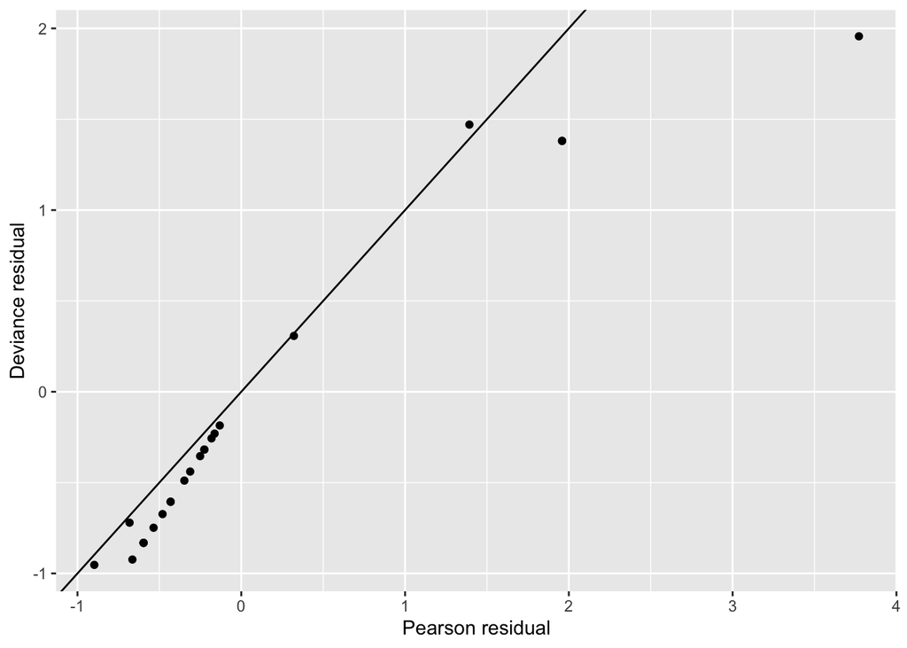

```r
tibble(rperson = residuals(binmod, type = "pearson"),
  rdeviance = residuals(binmod, type = "deviance")) %>%
  ggplot() +
  geom_point(mapping = aes(x = rperson, y =rdeviance)) +
  geom_abline(intercept = 0, slope = 1) +
  xlab("Pearson residual") +
  ylab("Deviance residual")
```